# ML with cart

CB

23 février 2020

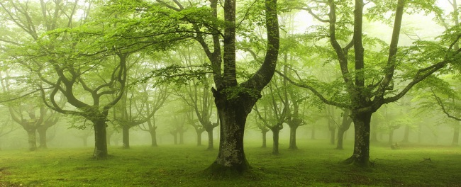

https://www.flickr.com/photos/zapirain/

L’objectif de cette note est double. Le premier est une introduction aux méthodes d’arbres de décision et leur généralisation récente par les random forests. Le second est d’introduire à l’approche d’apprentissage et de test, autrement aux machine learning avec le package caret qui facilite la condition des opérations d’échantillonngage, de découpage des échanges et de production des indicateurs.

# 1-Préparation des données

Les données sont extraites de l’ESS, une sélection est disponible. Elles couvrent les 9 vagues et concernent la France et L’allemagne. Les variables dépendantes (celles que l’on veut étudier et expliquer) sont les 9 items de la confiance, les variable considérées comme indépendantes (ou explicatives) sont une séléction de variables socio-démographiques : age, genre, perception du pouvoir d’achat, orientation politique, type d’habitat.

# 2 Construire un arbre de décision

## 2.1 Les origines et le principe

C’est une approche qui remonte à Morgan and Sonquist (1963)

généralisés aux variables qualitatives avec Chaid (Kass (1980)) :

Le principe général suis le pseudo algorithme suivant :

1. pour chaque variable potentiellement explicative, trouver le meilleur découpage (dichotomique), c’est à dire celui qui va différencier au mieux la variable de réponse.
2. Choisir parmi les variables et leur dichotomitsation celle qui répond au même critère que précedemment
3. recommencer l’opération à 1

Il peut s’appliquer à une variable quantitative ( regression) ou qualitative ( chaid)

puis Cart avec breiman. Breiman (1998)

## 2.2-Mise en oeuvre avec Partykit

avec partykit on contrôle la construction de l’arcre sur différents critères, par exemple : * le type de test employé pour prendre la décision * le nombre minimum d’individus dans une feuille terminale

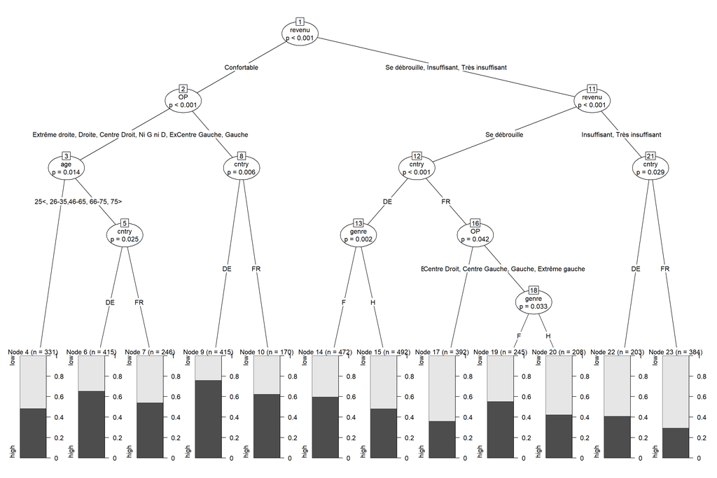

```r
#library(partykit)

tree <-ctree(conf ~ cntry+habitat + revenu +age+genre+OP+foyer, data=dfw,control = partykit::ctree_control(maxsurrogate = 5, alpha = 0.05,minsplit = 100, numsurrogate = TRUE))
plot(tree, tp_args = list(text = TRUE))
```

```r
#en plus beau on spécifie plus précisément les éléments de l'arbre
columncol<-hcl(c(270, 260, 250), 200, 30, 0.6)
labelcol<-hcl(200, 200, 50, 0.2)
indexcol<-hcl(150, 200, 50, 0.4)
jpeg("Tree.jpg", width=2000, height=750)
plot.new()
plot(tree, type = c("simple"), gp = gpar(fontsize = 15),
     drop_terminal = TRUE, tnex=1,
     inner_panel = node_inner(tree, abbreviate = TRUE,fill = c(labelcol, indexcol), pval = TRUE, id = TRUE), terminal_panel=node_barplot(tree, col = "black", fill = columncol[c(1,2,4)], beside = FALSE,ymax = 1, ylines = TRUE, widths = 1, gap = 0.1,reverse = FALSE, id = TRUE))
```

Pour évaluer la qualité du modèle, on utilise la fonction `predict` et on croise le résultat avec les observations. On utilise la fonction `confusionMatrix` pour calculer les différents indices de qualité dans l’esprit machine learning. Autrement la précision et le recall.

```r
table(predict(tree), dfw$conf)
```

```
##
##         low high
##   low  1189  821
##   high  721 1242
```

```r
pred<-as.data.frame(predict(tree))
mat <- confusionMatrix(data=pred$pred,reference=dfw$conf, positive="high")
print(mat)
```

```
## Confusion Matrix and Statistics
##
##           Reference
## Prediction  low high
##       low  1189  821
##       high  721 1242
##
##                Accuracy : 0.6119
##                  95% CI : (0.5965, 0.6271)
##     No Information Rate : 0.5193
##     P-Value [Acc > NIR] : <2e-16
##
##                   Kappa : 0.2241
##
##  Mcnemar's Test P-Value : 0.0117
##
##             Sensitivity : 0.6020
##             Specificity : 0.6225
##          Pos Pred Value : 0.6327
##          Neg Pred Value : 0.5915
##              Prevalence : 0.5193
##          Detection Rate : 0.3126
##    Detection Prevalence : 0.4941
##       Balanced Accuracy : 0.6123
##
##        'Positive' Class : high
##
```

```r
#accès aux indicateurs globaux
#print(mat$overall)
#print(mat$overall["Accuracy"])
print(mat$byClass)
```

```
##          Sensitivity          Specificity       Pos Pred Value
##            0.6020359            0.6225131            0.6327050
##       Neg Pred Value            Precision               Recall
##            0.5915423            0.6327050            0.6020359
##                   F1           Prevalence       Detection Rate
##            0.6169896            0.5192550            0.3126101
## Detection Prevalence    Balanced Accuracy
##            0.4940851            0.6122745
```

Dans un souci d’opérationnalisation, on peut souhaiter récupérer les règles pour reclasser d’autres observations. Le package `irks` peut s’en occuper.

```r
#creation des règles

library(irks)
rules<-ct_rules(tree)

rules %>%
  kable() %>%
  kable_styling(bootstrap_options = "striped", font_size = 10)
```

| node | rule |
| --- | --- |
| 4 | revenu %in% c(“Confortable”) & OP %in% c(“Extrême droite”, “Droite”, “Centre Droit”, “Ni G ni D”, “Extrême gauche”) & age %in% c(“25<”, “26-35”, “36-45”) |
| 6 | revenu %in% c(“Confortable”) & OP %in% c(“Extrême droite”, “Droite”, “Centre Droit”, “Ni G ni D”, “Extrême gauche”) & age %in% c(“46-65”, “66-75”, “75>”) & cntry %in% c(“DE”) |
| 7 | revenu %in% c(“Confortable”) & OP %in% c(“Extrême droite”, “Droite”, “Centre Droit”, “Ni G ni D”, “Extrême gauche”) & age %in% c(“46-65”, “66-75”, “75>”) & cntry %in% c(“FR”) |
| 9 | revenu %in% c(“Confortable”) & OP %in% c(“Centre Gauche”, “Gauche”) & cntry %in% c(“DE”) |
| 10 | revenu %in% c(“Confortable”) & OP %in% c(“Centre Gauche”, “Gauche”) & cntry %in% c(“FR”) |
| 14 | revenu %in% c(“Se débrouille”, “Insuffisant”, “Très insuffisant”) & revenu %in% c(“NA”, “Se débrouille”) & cntry %in% c(“DE”) & genre %in% c(“F”) |
| 15 | revenu %in% c(“Se débrouille”, “Insuffisant”, “Très insuffisant”) & revenu %in% c(“NA”, “Se débrouille”) & cntry %in% c(“DE”) & genre %in% c(“H”) |
| 17 | revenu %in% c(“Se débrouille”, “Insuffisant”, “Très insuffisant”) & revenu %in% c(“NA”, “Se débrouille”) & cntry %in% c(“FR”) & OP %in% c(“Extrême droite”, “Droite”, “Ni G ni D”) |
| 19 | revenu %in% c(“Se débrouille”, “Insuffisant”, “Très insuffisant”) & revenu %in% c(“NA”, “Se débrouille”) & cntry %in% c(“FR”) & OP %in% c(“Centre Droit”, “Centre Gauche”, “Gauche”, “Extrême gauche”) &… |
| 20 | revenu %in% c(“Se débrouille”, “Insuffisant”, “Très insuffisant”) & revenu %in% c(“NA”, “Se débrouille”) & cntry %in% c(“FR”) & OP %in% c(“Centre Droit”, “Centre Gauche”, “Gauche”, “Extrême gauche”) &… |
| 22 | revenu %in% c(“Se débrouille”, “Insuffisant”, “Très insuffisant”) & revenu %in% c(“NA”, “Insuffisant”, “Très insuffisant”) & cntry %in% c(“DE”) |
| 23 | revenu %in% c(“Se débrouille”, “Insuffisant”, “Très insuffisant”) & revenu %in% c(“NA”, “Insuffisant”, “Très insuffisant”) & cntry %in% c(“FR”) |

# Plus qu’un arbre, une forêt

Ces derniers années les arbres de décisions se sont enrichies par une approche ensembliste et une stratégie particulière. Plutôt que de construire un seul arbre, l’idée est d’en construire une forêt en perturbant les données : ne présenter qu’un sous échantillon des variables ou des observations. Une fois ces centaines ou milliers d’arbres construits, on les fait voter, à chaque niveau de découpage on reparge à travers les arbres celui qui a le meilleurs résultats, l’arbre final est donc une construction electorale! https://cran.r-project.org/web/packages/caret/vignettes/caret.html

https://topepo.github.io/caret/

```r
set.seed(3456)
trainIndex <- createDataPartition(dfw$conf, p = .3,
                                  list = FALSE,
                                  times = 1)
head(trainIndex)
```

```
##      Resample1
## [1,]         1
## [2,]         6
## [3,]         7
## [4,]        10
## [5,]        11
## [6,]        12
```

```r
dfTrain <- dfw[ trainIndex,]
dfTest  <- dfw[-trainIndex,]

fitControl <- trainControl()

m_rf <- train(conf ~ ., data = dfTrain, method="rf",trControl=fitControl)
print(m_rf)
```

```
## Random Forest
##
## 1265 samples
##    7 predictor
##    2 classes: 'low', 'high'
##
## No pre-processing
## Resampling: Bootstrapped (25 reps)
## Summary of sample sizes: 1265, 1265, 1265, 1265, 1265, 1265, ...
## Resampling results across tuning parameters:
##
##   mtry  Accuracy   Kappa
##    2    0.5633512  0.12897638
##   14    0.5385481  0.07802173
##   26    0.5337849  0.06862147
##
## Accuracy was used to select the optimal model using the largest value.
## The final value used for the model was mtry = 2.
```

```r
print(m_rf$finalModel)
```

```
##
## Call:
##  randomForest(x = x, y = y, mtry = param$mtry)
##                Type of random forest: classification
##                      Number of trees: 500
## No. of variables tried at each split: 2
##
##         OOB estimate of  error rate: 41.5%
## Confusion matrix:
##      low high class.error
## low  228  390   0.6310680
## high 135  512   0.2086553
```

# Validation

on predit maintenant sur l’échantillon test en réutilisant la fonction confusionMatrix.

```r
pred <- predict(m_rf,newdata=dfTest,na.action = na.pass)
pred<-as.data.frame(pred)
mat <- confusionMatrix(data=pred$pred,reference=dfTest$conf, positive="high")
print(mat)
```

```
## Confusion Matrix and Statistics
##
##           Reference
## Prediction  low high
##       low   482  299
##       high  960 1210
##
##                Accuracy : 0.5734
##                  95% CI : (0.5553, 0.5913)
##     No Information Rate : 0.5114
##     P-Value [Acc > NIR] : 8.172e-12
##
##                   Kappa : 0.1375
##
##  Mcnemar's Test P-Value : < 2.2e-16
##
##             Sensitivity : 0.8019
##             Specificity : 0.3343
##          Pos Pred Value : 0.5576
##          Neg Pred Value : 0.6172
##              Prevalence : 0.5114
##          Detection Rate : 0.4100
##    Detection Prevalence : 0.7353
##       Balanced Accuracy : 0.5681
##
##        'Positive' Class : high
##
```

```r
#accès aux indicateurs globaux
#print(mat$overall)
#print(mat$overall["Accuracy"])
print(mat$byClass)
```

```
##          Sensitivity          Specificity       Pos Pred Value
##            0.8018555            0.3342580            0.5576037
##       Neg Pred Value            Precision               Recall
##            0.6171575            0.5576037            0.8018555
##                   F1           Prevalence       Detection Rate
##            0.6577874            0.5113521            0.4100305
## Detection Prevalence    Balanced Accuracy
##            0.7353440            0.5680568
```

```r
library(pROC)
```

# Importance des variables

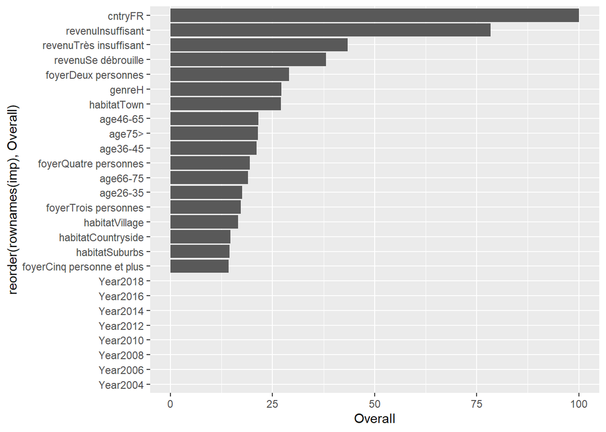

```r
imp<-varImp(m_rf)
imp<-imp[[1]]
ggplot(imp, aes(x=reorder(rownames(imp),Overall), y=Overall))+geom_bar(stat="identity")+coord_flip()
```

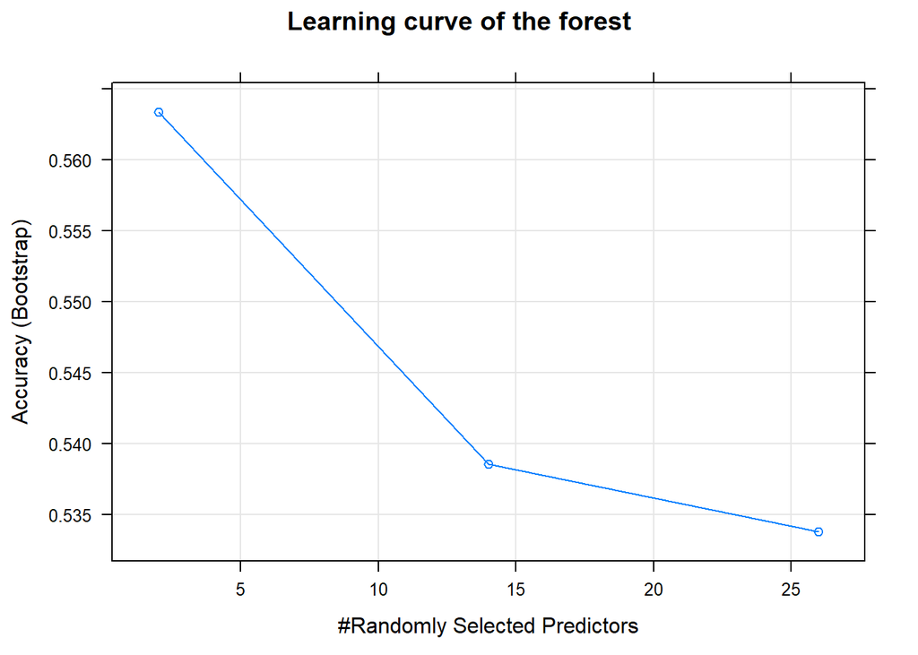

```r
plot(m_rf, main = "Learning curve of the forest")
```

# Expliquer les predictions

On utilise le package [`randomForestExplainer`](https://cran.rstudio.com/web/packages/randomForestExplainer/vignettes/randomForestExplainer.html) à cette fin

Une première méthode consiste à examiner la distribution de la profondeur minimal. Celle-ci indique à quel niveau minimal ( donc le plus proche de la racine) une variable est utilisée pour découper la population.

On extrait d’abord ces valeurs (pour chacun des arbres construits par le rf). comme le calcul est long on en sauve le résultat dans un fichier qu’on va exploiter ensuite

```r
library(randomForestExplainer)

forest <- randomForest(conf ~ ., data = dfw, localImp = TRUE)
min_depth_frame <- min_depth_distribution(forest)
save(min_depth_frame, file = "min_depth_frame.rda")
```

On trace le diagramme

Ensuite, nous le passons à la fonction plot_min_depth_distribution et, sous les paramètres par défaut, nous obtenons un tracé de la distribution de la profondeur minimale pour les variables les plus importantes en fonction de la profondeur minimale moyenne calculée à l’aide des arbres supérieurs (mean_sample = “top_trees”). Nous pourrions également passer notre forêt directement à la fonction de traçage, mais si nous voulons faire plusieurs tracés de la distribution de la profondeur minimale, il est plus efficace de passer le cadre min_depth_frame à la fonction de traçage afin qu’il ne soit pas calculé à nouveau pour chaque tracé (cela fonctionne de la même manière pour les autres fonctions de traçage de randomForestExplainer).

```r
load("min_depth_frame.rda")
head(min_depth_frame, n = 10)
```

```
##    tree variable minimal_depth
## 1     1      age             3
## 2     1    cntry             3
## 3     1    foyer             1
## 4     1    genre             1
## 5     1  habitat             0
## 6     1   revenu             2
## 7     2      age             2
## 8     2    cntry             2
## 9     2    foyer             0
## 10    2    genre             4
```

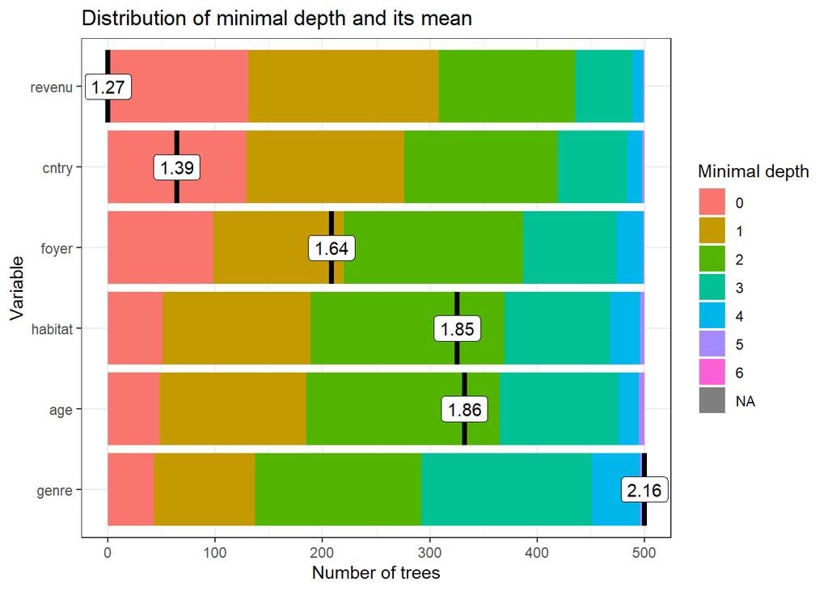

```r
plot_min_depth_distribution(min_depth_frame, mean_sample = "relevant_trees", k = 15)
```

d’autres mesures sont disponibles avec measure_importance, et on agit de la même manière.

- accuracy_decrease (classification) – mean decrease of prediction accuracy after Xj is permuted,
- gini_decrease (classification) – mean decrease in the Gini index of node impurity (i.e. increase of node purity) by splits on Xj,
- mse_increase (regression) – mean increase of mean squared error after Xjis permuted,
- node_purity_increase (regression) – mean node purity increase by splits on Xj, as measured by the decrease in sum of squares,
- mean_minimal_depth – mean minimal depth calculated in one of three ways specified by the parameter mean_sample,
- no_of_trees – total number of trees in which a split on Xj occurs,
- no_of_nodes – total number of nodes that use Xj for splitting (it is usually equal to no_of_trees if trees are shallow),
- times_a_root – total number of trees in which Xjis used for splitting the root node (i.e., the whole sample is divided into two based on the value of Xj),
- p_value –This test tells us whether the observed number of successes (number of nodes in which Xj was used for splitting) exceeds the theoretical number of successes if they were random (i.e. following the binomial distribution given above).

```r
importance_frame <- measure_importance(forest)
save(importance_frame, file = "importance_frame.rda")
load("importance_frame.rda")
importance_frame
```

```
##   variable mean_min_depth no_of_nodes accuracy_decrease gini_decrease
## 1      age          1.864       18852      0.0029123438      60.36012
## 2    cntry          1.388        5016      0.0228826648      40.66763
## 3    foyer          1.644       16744      0.0053621202      49.72321
## 4    genre          2.162        8049      0.0050381821      19.02649
## 5  habitat          1.852       17463      0.0003074018      49.40158
## 6   revenu          1.274       11692      0.0343971213      81.52406
## 7     Year             NA           0      0.0000000000       0.00000
##   no_of_trees times_a_root      p_value
## 1         500           48 0.000000e+00
## 2         500          129 1.000000e+00
## 3         500           98 0.000000e+00
## 4         500           43 1.000000e+00
## 5         500           51 0.000000e+00
## 6         500          131 2.462789e-09
## 7           0            0 1.000000e+00
```

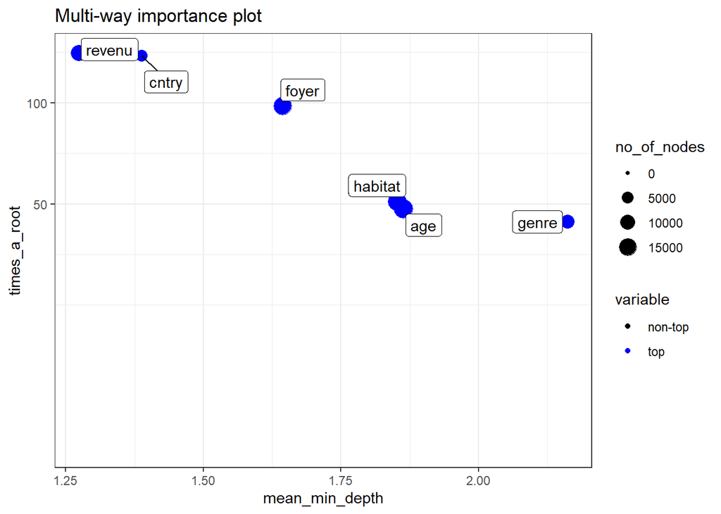

```r
plot_multi_way_importance(importance_frame, size_measure = "no_of_nodes")
```

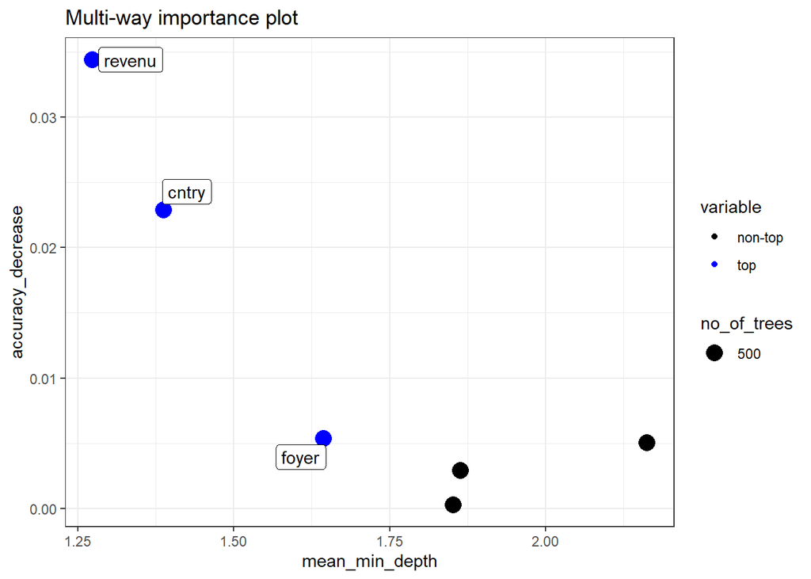

```r
plot_multi_way_importance(importance_frame, x_measure = "mean_min_depth", y_measure = "accuracy_decrease", size_measure = "no_of_trees", no_of_labels = 3)
```

```r
#plot_importance_rankings(importance_frame)
```

[voir aussi](https://cdn.staticaly.com/gh/geneticsMiNIng/BlackBoxOpener/master/randomForestExplainer/inst/doc/randomForestExplainer.html)

# En conclusion

Des tutoriels : On s’est inspiré de  
http://mehdikhaneboubi.free.fr/random_forest_r.html

# Références

Breiman, Leo, ed. 1998. *Classification and Regression Trees*. Repr. Boca Raton: Chapman & Hall [u.a.].

Hothorn, Torsten, Kurt Hornik, Mark A van de Wiel, and Achim Zeileis. 2006. “A Lego System for Conditional Inference.” *The American Statistician* 60 (3): 257–63. https://doi.org/10.1198/000313006X118430.

Hothorn, Torsten, and Achim Zeileis. 2015. “Partykit: A Modular Toolkit for Recursive Partytioning in R.” *Journal of Machine Learning Research* 16 (118): 3905–9. http://jmlr.org/papers/v16/hothorn15a.html.

Kass, G. V. 1980. “An Exploratory Technique for Investigating Large Quantities of Categorical Data.” *Applied Statistics* 29 (2): 119. https://doi.org/10.2307/2986296.

Morgan, James N., and John A. Sonquist. 1963. “Problems in the Analysis of Survey Data, and a Proposal.” *Journal of the American Statistical Association* 58 (302): 415–34. https://doi.org/10.1080/01621459.1963.10500855.